# Projet de Jump Process

### Thomas JOUVE | Paul-Louis CABAL | Théo MIDAVAINE | Matthieu JULIEN

```python
import numpy as np
import pandas as pd
import scipy as si
from scipy.stats import norm
from scipy.stats import levy_stable
import matplotlib.pyplot as plt
from scipy.stats import norm
import sympy as sp
from sympy import symbols, Eq, solve
from sympy import solve_poly_system
from sympy.abc import x, y
```

### 1. Using the code for the Merton model as a blueprint, implement the Monte Carlo simulation of the Kou jump diffusion model.

```python
def MonteCarloSimulation_Kou(simN, stepsN, S0, T, r, q, params):

    np.random.seed(123)
    sigma, lam, p, lam_plus, lam_minus = params
    dt = T / stepsN
    price = np.ones((simN, stepsN + 1)) * S0
    jump_compensator = (lam * (p * lam_plus / (lam_plus - 1) + (1 - p) * lam_minus / (1 + lam_minus) - 1))
    drift = (r - q - sigma ** 2 / 2 - jump_compensator) * dt * np.ones((simN, stepsN))

    dWt = np.random.normal(0, 1, (simN, stepsN))
    diffusion = sigma * dWt * np.sqrt(dt)

    jump_N = si.stats.poisson.rvs(lam * dt, size=(simN, stepsN))
    jumps = np.zeros((simN, stepsN))

    for i in range(simN):
        for j in range(stepsN):
            for k in range(jump_N[i, j]):
                U = np.random.rand(1)
                jumps[i, j] += np.random.exponential(1 / lam_plus) * (U < p) - np.random.exponential(1 / lam_minus) * (U > p)

    price[:, 1:] = S0 * np.exp(np.cumsum(drift + diffusion + jumps, axis=1))

    mart = np.exp(-r * T) * np.mean(price[:, -1])

    return price
```

```python
def plot_paths(paths):
    for i in range(paths.shape[0]):
        plt.plot(paths[i, :], linewidth=0.5)

    plt.title('Monte Carlo Simulation Paths')
    plt.xlabel('Time Steps')
    plt.ylabel('Asset Price')
    plt.show()
```

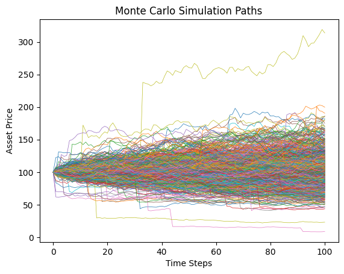

```python
#we test with chosen values for each parameters
paths=MonteCarloSimulation_Kou(1000,100, 100, 1, 0.02, 0, [0.2,0.5,0.6,10,5])
plot_paths(paths)
```

Implement the Lewis integral option pricing formula for the model

```python
def cgmy(params, z):
    C, G, M, Y = params
    return C * si.special.gamma(-Y) * ((M - 1j * z) ** Y - M ** Y + (G + 1j * z) ** Y - G ** Y)

def merton(params, z):
    sigma, lam, mu, delta = params
    return lam * (np.exp(1j * z * mu - 0.5 * delta**2 * z**2) - 1) -0.5 * (z**2) * sigma**2

def nig(params, z):
    kappa, sigma, mu = params
    return (1 - np.sqrt(1 + z**2 * sigma**2 * kappa - 2 * 1j * mu * z * kappa)) / kappa

def characteristic_exponent(model, params, z):

    functions = {
        'CGMY': cgmy,
        'MERTON': merton,
        'NIG': nig,
    }

    if model not in functions:
        raise ValueError('Characteristic exponent not available')

    return functions[model](params, z)
```

```python
def characteristic_function(z, S0, T, r, q, params, model):

    if model in {'NIG', 'MERTON', 'CGMY'}:
        ce = T * (characteristic_exponent(model, params, z) -
                  1j * z * characteristic_exponent(model, params, -1j))
        cf = np.exp(1j * z * (np.log(S0) + T * (r - q)) + ce)

    elif model == 'HESTON':
        v0, kappa, theta, eta, rho = params
        d = np.sqrt((rho * eta * 1j * z - kappa)**2 + eta**2 * (1j * z + z**2))
        g = (kappa - rho * eta * 1j * z - d) / (kappa - rho * eta * 1j * z + d)
        A = theta * kappa / (eta**2) * ((kappa - rho * eta * 1j * z - d) * T - 2 * np.log((1 - g * np.exp(-d * T)) / (1 - g)))
        B = v0 / eta**2 * (kappa - rho * eta * 1j * z - d) * (1 - np.exp(-d * T)) / (1 - g * np.exp(-d * T))
        cf = np.exp(1j * z * (np.log(S0) + (r - q) * T) + A + B)

    else:
        raise ValueError('Characteristic function not available')

    return cf
```

```python
def Lewis_Pricing(S0, K, T, r, q, params, trunc, im, model):

    def integrand(om, S0, K, T, r, q, params, im, model):
        i = 1j
        z = om + i * im
        return characteristic_function(-z, S0, T, r, q, params, model) * K ** (1 + i * z) / (i * z - z ** 2)

    call, _ = si.integrate.quad(integrand, -trunc, trunc, args=(S0, K, T, r, q, params, im, model))

    call *= 0.5 * np.exp(-r * T) / np.pi
    call = abs(call)

    return call
```

### 2. Implement the Monte Carlo simulation of a Bilateral Gamma option pricing model (difference of two Gamma subordinators) and as a particular case reproduce the Variance Gamma model as originally introduced as the exponential of a subordinated Brownian motion.

First we solve to find the vlaue or theta + and theta -

```python
sigma, kappa, mu = symbols('sigma, kappa, mu')
```

We set x = theta_plus and y = theta_minus, then we get this equation to solve :

```python
solutions = solve_poly_system([x*y-2/(sigma**2*kappa),y-x-(2*mu)/(sigma**2)], x, y)
solutions
```

```
[((-2*mu + sigma**2*(mu/sigma**2 - sqrt(kappa*(kappa*mu**2 + 2*sigma**2))/(kappa*sigma**2)))/sigma**2,
  mu/sigma**2 - sqrt(kappa*(kappa*mu**2 + 2*sigma**2))/(kappa*sigma**2)),
 ((-2*mu + sigma**2*(mu/sigma**2 + sqrt(kappa*(kappa*mu**2 + 2*sigma**2))/(kappa*sigma**2)))/sigma**2,
  mu/sigma**2 + sqrt(kappa*(kappa*mu**2 + 2*sigma**2))/(kappa*sigma**2))]
```

We can test our set of solutions to see if we get 0

```python
(solutions[1][1] - solutions[1][0] - 2*mu/sigma**2).subs({sigma: 0.2, kappa: 0.1, mu: 0.05})
```

$\displaystyle 0$

```python
(solutions[1][1] - solutions[1][0] - 2*mu/sigma**2).subs({sigma: 0.2, kappa: 0.1, mu: 0.05})
```

$\displaystyle 0$

```python
round((solutions[0][1] * solutions[0][0]- 2/(kappa*sigma**2)).subs({sigma: 0.2, kappa: 0.1, mu: 0.05}))
```

$\displaystyle 0$

```python
round((solutions[1][1] * solutions[1][0]- 2/(kappa*sigma**2)).subs({sigma: 0.2, kappa: 0.1, mu: 0.05}))
```

$\displaystyle 0$

Thus, our set of solution for (x,y) are correct

$$ \theta + : \left( \frac{-\kappa\mu - \sqrt{\kappa(\kappa\mu^2 + 2\sigma^2)}}{\kappa\sigma^2}, \frac{\kappa\mu - \sqrt{\kappa(\kappa\mu^2 + 2\sigma^2)}}{\kappa\sigma^2} \right)\\ \theta - : \left( \frac{-\kappa\mu + \sqrt{\kappa(\kappa\mu^2 + 2\sigma^2)}}{\kappa\sigma^2}, \frac{\kappa\mu + \sqrt{\kappa(\kappa\mu^2 + 2\sigma^2)}}{\kappa\sigma^2} \right) $$

We set sigma = 0.2, kappa = 1, mu = 0.05

```python
mu_val = 0.05
kappa_val = 1.
sigma_val = 0.2
```

```python
theta_plus_sol1 = (solutions[0][0]).subs({sigma: sigma_val, kappa: kappa_val, mu: mu_val})
theta_moins_sol1 = (solutions[0][1]).subs({sigma: sigma_val, kappa: kappa_val, mu: mu_val})
solution_1 = [theta_plus_sol1,theta_moins_sol1]
solution_1
```

```
[-8.43070330817254, -5.93070330817254]
```

```python
theta_plus_sol2 = (solutions[1][0]).subs({sigma: sigma_val, kappa: kappa_val, mu: mu_val})
theta_moins_sol2 = (solutions[1][1]).subs({sigma: sigma_val, kappa: kappa_val, mu: mu_val})
solution_2 = [theta_plus_sol2,theta_moins_sol2]
solution_2
```

```
[5.93070330817254, 8.43070330817254]
```

We want positive values for thetas, therefore, we will be using the second set of parameters.

```python
print(f"theta_plus = {solution_2[0]} , theta_minus = {solution_2[1]}")
```

```
theta_plus = 5.93070330817254 , theta_minus = 8.43070330817254
```

Let's implement the Monte Carlo simulation of a Bilateral Gamma option pricing model

```python
K = 100
S0 = 100
r = 0.02
T = 1
nb_simulations = 1000
nb_steps = 100
sigma = 0.2
kappa = 1.
mu = 0.05

theta_plus, theta_minus = solution_2


def valorisation_Monte_Carlo(S0, r, nb_simulations, nb_steps, strike, T, theta_plus, theta_minus):
    dt = T / nb_steps
    paths = np.zeros((nb_simulations, nb_steps + 1))
    paths[:,0] = S0

    for i in range(nb_steps):
        # We Generate two Gamma processes for theta_plus and theta_minus
        gamma_plus = np.random.gamma(scale=dt/theta_plus, shape=theta_plus, size=nb_simulations)
        gamma_minus = np.random.gamma(scale=dt/theta_minus, shape=theta_minus, size=nb_simulations)

        #Variance-Gamma model can be written as the difference of two independent gamma processes:
        VG = gamma_plus - gamma_minus
        paths[:,i+1] = paths[:, i] * np.exp(VG - r*dt)


    option_payoffs = np.maximum(paths[:,-1] - strike, 0)
    option_value = np.exp(-r * T) * np.mean(option_payoffs)
    return paths


paths = valorisation_Monte_Carlo(S0, r, nb_simulations, nb_steps, K, T, theta_plus, theta_minus)
```

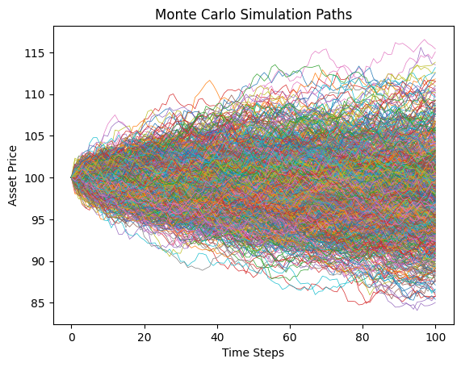

```python
plot_paths(paths)
```

3.Using the acceptance rejection code (AR) for simulating positive tempered stable random variables, implement an exact Monte Carlo simulator for the CGMY model with α ∈ (0, 1). A CGMY process in that case will be just a difference of Tempered Stable subordinators. Follow the papers of Kawai and Masuda (2011) and Zhang and Zhang (2018). Beware of the many possible different parametrisations when using a stable random number generator.

```python
import numpy as np
from scipy.stats import levy_stable

def CGMY_Final_MC(simN, S0, T, r, q, params, time_steps):
    C, G, M, Y = params

    # Calculate lambda and compensator
    lambda_Y = (C * np.math.gamma(1 - Y) / Y * np.cos(np.pi * Y / 2) * T) ** (1 / Y)
    compensator = C * np.math.gamma(-Y) * ((M - 1) ** Y - M ** Y + (G + 1) ** Y - G ** Y) * T

    # Initialize arrays
    price_paths = np.zeros((simN, time_steps))
    price_paths[:, 0] = S0

    dt = T / (time_steps - 1)

    np.random.seed(123)  # for reproducibility

    for i in range(1, time_steps):
        # Generate jump sizes
        jump_plus = np.zeros(simN)
        jump_minus = np.zeros(simN)

        for j in range(simN):
            accepted = False
            while not accepted:
                jump = lambda_Y * levy_stable.rvs(Y, 1, loc=0, scale=1, size=1)
                U = np.random.rand()
                if np.exp(-M * jump) > U:
                    jump_plus[j] = jump
                    accepted = True

            accepted = False
            while not accepted:
                jump = lambda_Y * levy_stable.rvs(Y, 1, loc=0, scale=1, size=1)
                V = np.random.rand()
                if np.exp(-G * jump) > V:
                    jump_minus[j] = jump
                    accepted = True

        # Debug output because had issues with jump values
        if i % 10 == 0:  # Print debug information every 10 steps
            print(f"Time step {i}, sample jump_plus: {jump_plus[:5]}, jump_minus: {jump_minus[:5]}")

        # Compute price paths
        price_paths[:, i] = price_paths[:, i-1] * np.exp((r - q - compensator) * dt + jump_plus - jump_minus)

        # Debug output to check for non-positive prices
        if (price_paths[:, i] <= 0).any():
            print(f"Non-positive prices found at time step {i}")
            break

    return price_paths
```

We try with basic parameters

```python
# Define the parameters
simN = 1000
S0 = 100
T = 1
r = 0.01
q = 0.02

params = (0.5, 0.5, 0.5, 0.5)
time_steps = 252  # Assume 252 trading days in a year

# Run the Monte Carlo simulation
price_paths = CGMY_Final_MC(simN, S0, T, r, q, params, time_steps)

# Analysis 1: Frequency Histograms for Log-Prices
final_prices = price_paths[:, -1]


# Exclude non-positive final prices before taking the logarithm
positive_final_prices = final_prices[final_prices > 0]
if len(positive_final_prices) == 0:
    raise ValueError("All final prices are non-positive, check the model parameters and simulation.")
```

[output not shown]

Path, Log prices and log returns

```python
max_price_path_value = np.max(price_paths)
min_price_path_value = np.min(price_paths)

print(f"Maximum price path value: {max_price_path_value}")
print(f"Minimum price path value: {min_price_path_value}")
if max_price_path_value > 1e100 or min_price_path_value < 1e-100:
    print("Warning: Extreme values detected in price paths.")

# Plot a subset of paths
plt.figure(figsize=(10, 6))
for path in price_paths[:10, :]:  # Plot only the first 10 paths for clarity
    plt.plot(time_grid, path)
plt.yscale('log')  # Log scale for better visibility in case of extreme values
plt.xlabel('Time')
plt.ylabel('Price')
plt.title('CGMY Price Paths')
plt.show()



# Calculate log-prices with a filter for positive final prices
log_prices = np.log(final_prices[final_prices > 0] / S0)

# Plot histogram within a specified range to avoid extreme values
plt.hist(log_prices, bins=50, range=[np.percentile(log_prices, 1), np.percentile(log_prices, 99)], alpha=0.75)
plt.xlabel('Log-Price')
plt.ylabel('Frequency')
plt.title('Frequency Histogram of Log-Prices')
plt.show()

# Calculate log returns
log_returns = np.log(final_prices / S0)
plt.hist(log_returns, bins=50, density=True, alpha=0.75)
plt.title('Returns CGMY model T=1')
plt.xlabel('Log return')
plt.ylabel('Density')
plt.show()
```

[output not shown]

Now with the value determined in the Zhang and Zhang paper in the 6.2 section : C = 0.42, G = 4.37, M = 191.2 and Y = 1.0102

```python
simN = 1000
S0 = 100
T = 1
r = 0.01
q = 0.02
time_steps = 252  # Assume 252 trading days in a year
params2 = (0.42, 4.37, 191.2, 1.0102)
price_pathsZZ = CGMY_Final_MC(simN, S0, T, r, q, params2, time_steps)


# Analysis 1: Frequency Histograms for Log-Prices
final_pricesZZ = price_pathsZZ[:, -1]


# Exclude non-positive final prices before taking the logarithm
positive_final_pricesZZ = final_pricesZZ[final_pricesZZ > 0]
if len(positive_final_pricesZZ) == 0:
    raise ValueError("All final prices are non-positive, check the model parameters and simulation.")


max_price_path_valueZZ = np.max(price_pathsZZ)
min_price_path_valueZZ = np.min(price_pathsZZ)

print(f"Maximum price path value: {max_price_path_valueZZ}")
print(f"Minimum price path value: {min_price_path_valueZZ}")
if max_price_path_valueZZ > 1e100 or min_price_path_valueZZ < 1e-100:
    print("Warning: Extreme values detected in price paths.")

# Plot a subset of paths
plt.figure(figsize=(10, 6))
for pathZ in price_pathsZZ[:10, :]:  # Plot only the first 10 paths for clarity
    plt.plot(time_grid, pathZ)
plt.yscale('log')  # Log scale for better visibility in case of extreme values
plt.xlabel('Time')
plt.ylabel('Price')
plt.title('CGMY Price Paths')
plt.show()



# Calculate log-prices with a filter for positive final prices
log_pricesZZ = np.log(final_pricesZZ[final_pricesZZ > 0] / S0)

# Plot histogram within a specified range to avoid extreme values
plt.hist(log_pricesZZ, bins=50, range=[np.percentile(log_pricesZZ, 1), np.percentile(log_pricesZZ, 99)], alpha=0.75)
plt.xlabel('Log-Price')
plt.ylabel('Frequency')
plt.title('Frequency Histogram of Log-Prices')
plt.show()

# Calculate log returns
log_returnsZZ = np.log(final_pricesZZ / S0)
plt.hist(log_returnsZZ, bins=50, density=True, alpha=0.75)
plt.title('Returns CGMY model T=1')
plt.xlabel('Log return')
plt.ylabel('Density')
plt.show()
```

[output not shown]

In summary, the three charts suggest that there are significant problems with the simulation. It would be necessary to review the model parameters to ensure they are realistic and check the numerical methods used for the simulation to ensure they are stable and accurate.

Extra assignment for bonus points. If you want to speed up the code, try the double AR algorithm mentioned in Zhang and Zhang (2018).

```python
def A(u, Y):
    if u == 0:
        return 1
    else:
        return ((np.sin(Y * u)) ** Y * (np.sin((1 - Y) * u)) ** (1 - Y)) / (np.sin(u) ** Y)

def B(x, T, Y):

    if x == 0:
        return (Y - 1) ** Y * Y ** (-Y)
    else:
        return A(x, Y) * (x ** (1 - Y))

def double_rejection(C, G, M, Y, T):
    # Formula of the paper

    lambda_Y = C * T * ((M - 1) ** Y - M ** Y + (G + 1) ** Y - G ** Y)
    gamma = M ** Y + G ** Y - (M ** Y) * (G ** Y)
    y1 = -np.pi / 2 * Y
    y2 = np.pi / 2 * (1 - Y)
    u1 = y2 / (y1 + y2)
    u2 = y1 / (y1 + y2)
    u3 = np.pi
    b = (1 - Y) / Y
    c = np.pi ** (2 * Y) / np.sin(np.pi * Y)

    while True:
        # Step 1: Generate V and W' uniformly on [0, 1]
        V = np.random.uniform(0, 1)
        W_prime = np.random.uniform(0, 1)


        print(V, W_prime)


        return None

C = 1.0
G = 5.0
M = 10.0
Y = 0.5
T = 1.0

sample = double_rejection(C, G, M, Y, T)
print(sample)
```

# Question 4 :

```python
import numpy as np
import scipy as si
import scipy.integrate as si2
from scipy.integrate import quad
from scipy.stats import norm
from scipy.stats import stats
from scipy.stats import levy_stable
import matplotlib.pyplot as plt
from scipy.stats import norm
from scipy.optimize import fsolve
```

# Characteristic function of the BNS model in the case of Z being a CPP process with exponential jumps

```python
def characteristic_function_BNS2(z, S, T, r, q, params):
      alpha, beta, rho, _lambda, sigma = params
      f1 = 1j * z * rho - (1 / _lambda) * (z ** 2 + 1j * z) * (1 - np.exp(-_lambda * T)) / 2
      f2 = 1j * z * rho - (1 / _lambda) * (z ** 2 + 1j * z) / 2


      cf1 = 1j * z * (np.log(S) + (r - q - alpha * _lambda * rho * (1 / (beta - rho))) * T)
      cf2 = (1 / _lambda) * (z ** 2 + 1j * z) * (1 - np.exp(-_lambda * T)) * (sigma ** 2) / 2
      cf3 = alpha * (1 / (beta - f2)) * (beta * np.log((beta - f1) / (beta - 1j * z * rho)) + f2 * _lambda * (-T))

      temp = cf1 - cf2 + cf3
      cf_result = np.exp(temp)
      return cf_result
```

# Lewis integral option pricing formula for such model

```python
# Lewis pricing using the characteristic function (Given by our professor)
def CallPricingLewis_eta(S0, K, T, r, q, params, trunc, im):
    def integrand(om, S0, K, T, r, q, params, im):
        i = 1j
        z = om + i * im
        return characteristic_function_BNS2(-z, S0, T, r, q, params) * (K ** (1 + i * z) / (i * z - z ** 2)) * np.exp(-1j * z * (np.log(S0 + (r - q)*T)))

    # Use quad for numerical integration
    call, _ = si2.quad(integrand, -trunc, trunc, args=(S0, K, T, r, q, params, im))

    call *= 0.5 * np.exp(-r * T) / np.pi
    call = abs(call)

    return call


params = [2.9, 0.2, 0.8, 0.08, 0.5]  #alpha, beta, rho, _lambda, sigma
trunc = np.inf  # Numerical truncation value
im = 0.5  # Imaginary part for the characteristic function
model = 'BNS'  # The model used for the characteristic function

# Spot price, strike price, time to maturity, risk-free rate, and dividend yield
S0 = 100
K = 100
T = 1
r = 0.02
q = 0.00

call_price_BNS = CallPricingLewis_eta(S0, K, T, r, q, params, trunc, im)
call_price_BNS
```

```
11.24376286720878
```

# Levy subordinator Z of infinite activity, and implement the pricing integral for the corresponding BNS model

```python
import scipy.integrate as si

def characteristic_function_BNS2_with_Levy(z, S, T, r, q, params):
    alpha, beta, rho, _lambda, sigma = params
    f1 = 1j * z * rho - (1 / _lambda) * (z ** 2 + 1j * z) * (1 - np.exp(-_lambda * T)) / 2
    f2 = 1j * z * rho - (1 / _lambda) * (z ** 2 + 1j * z) / 2

    cf1 = 1j * z * (np.log(S) + (r - q - alpha * _lambda * rho * (1 / (beta - rho))) * T)
    cf2 = (1 / _lambda) * (z ** 2 + 1j * z) * (1 - np.exp(-_lambda * T)) * (sigma ** 2) / 2
    cf3 = alpha * (1 / (beta - f2)) * (beta * np.log((beta - f1) / (beta - 1j * z * rho)) + f2 * _lambda * (-T))

    gamma = 0.1  # Drift parameter for the Lévy subordinator
    delta = 0.2  # Volatility parameter for the continuous part of the Lévy subordinator

    levy_effect = T * (1j * z * gamma - 0.5 * delta ** 2 * z ** 2)

    temp = cf1 - cf2 + cf3 + levy_effect
    cf_result = np.exp(temp)
    return cf_result

def CallPricingLewis_eta_with_Levy(S0, K, T, r, q, params, trunc, im):
    def integrand(om, S0, K, T, r, q, params, im):
        i = 1j
        z = om + i * im
        return characteristic_function_BNS2_with_Levy(-z, S0, T, r, q, params) * (K ** (1 + i * z) / (i * z - z ** 2)) * np.exp(-1j * z * (np.log(S0 + (r - q)*T)))

    # Numerical integration over the specified range
    call, _ = si.quad(integrand, -trunc, trunc, args=(S0, K, T, r, q, params, im))

    # Final adjustment to the call price formula
    call *= 0.5 * np.exp(-r * T) / np.pi
    call = abs(call)  # Ensure the call price is non-negative
    return call

# Parameters and inputs for the call price calculation
params_levy_sub = [2.8, 0.2, 0.8, 0.08, 0.5]  # alpha, beta, rho, _lambda, sigma
trunc = 100  # Large truncation value for numerical integration
im = 0.5  # Imaginary part for the characteristic function adjustment
S0, K, T, r, q = 100, 100, 1, 0.05, 0.00  # Spot, strike, maturity, rate, and yield

# Calculate the call price using the modified characteristic function
call_price_with_levy = CallPricingLewis_eta_with_Levy(S0, K, T, r, q, params_levy_sub, trunc, im)
print(f"Call Price with Levy Subordinator: {call_price_with_levy}")
```

```
Call Price with Levy Subordinator: 12.579853578445508
```

```python
# Define a function to simulate asset paths using the Variance Gamma process
def simulate_vg_option_price(S0, K, T, r, q, sigma, theta, kappa, nu, num_paths, num_steps):
    """
    Simulate asset prices using the Variance Gamma (VG) process and calculate the European call option price.
    """
    dt = T / num_steps  # Time step
    # The Variance Gamma process requires simulating a Brownian motion (dW)
    # and a Gamma process (dG)
    dW = np.random.normal(0, np.sqrt(dt), size=(num_paths, num_steps))
    dG = np.random.gamma(dt / nu, nu, size=(num_paths, num_steps))

    # Adjust the drift and diffusion terms according to the VG model
    # The drift should be adjusted by subtracting the term theta * kappa
    # The diffusion term now includes the square root of dG, the gamma process
    log_S = np.log(S0) + np.cumsum((r - q - theta * kappa) * dt + theta * dG + sigma * np.sqrt(dG) * dW, axis=1)

    # Convert log prices back to regular prices
    S = np.exp(log_S)

    # Prepend the initial asset prices to the simulated paths
    S = np.hstack((S0 * np.ones((num_paths, 1)), S))

    # Calculate the payoff for each path at maturity for a call option
    payoffs = np.maximum(S[:, -1] - K, 0)

    # Calculate the option price as the present value of the expected payoff
    option_price = np.exp(-r * T) * np.mean(payoffs)

    return option_price
```

Theta (θ) The parameter θ represents the drift of the Variance Gamma process. In financial terms, drift can be thought of as the average trend or direction in which the price of the underlying asset is expected to move over a given period. A positive θ would indicate a general upward trend in the asset price, while a negative θ would indicate a downward trend.

In the VG model, θ adjusts the process so that it can better fit the asymmetries observed in the returns of real assets, allowing the process to lean towards either positive or negative returns. This helps to capture the market's skewness.

Kappa (κ) The parameter κ, sometimes referred to as the variance rate or scale parameter, is related to the volatility of the returns of the underlying asset in the VG model. Specifically, it controls the rate at which variance "arrives" in the process, since the VG process is a Lévy process used to model jumps in asset prices.

A smaller κ means that variance arrives at a faster pace, indicating more frequent jumps and thus a return distribution with heavier tails (high kurtosis). This is characteristic of a leptokurtic distribution, where extreme events are more likely than those predicted by a normal (Gaussian) distribution. Conversely, a larger κ implies a slower arrival of variance, with less frequent jumps and a return distribution closer to normal.

In practice, θ and κ are adjusted to fit historical asset price data or to match market prices of derivative instruments. They are crucial for capturing the unique characteristics of the underlying asset's return distribution, thereby enabling a more accurate option valuation.

Change the MC simulator from the tutorials in a similar vein and compare option prices/implied volatilities.

```python
def BNS_MC_CallPrice(simN, stepsN, S0, K, T, r, q, params):
    """
    Monte Carlo simulation for call option pricing under the BNS model.

    Parameters
    ----------
    simN : int
        Number of simulations.
    stepsN : int
        Number of time steps.
    S0 : float
        Spot price of the underlying asset.
    K : float
        Strike price of the call option.
    T : float
        Time to maturity (in years).
    r : float
        Risk-free interest rate.
    q : float
        Continuous dividend yield.
    params : list
        Model parameters: v0 (initial variance), alpha, rho, lambda_ (jump intensity), theta (jump size).

    Returns
    -------
    call_price : float
        Simulated call option price.
    """
    v0, alpha, rho, lambda_, theta = params

    dt = T / stepsN
    logPrice = np.log(S0) + np.zeros((simN, stepsN + 1))
    variance = v0 * np.ones((simN, stepsN + 1))

    dWt = np.random.normal(0, 1, size=(simN, stepsN))

    sqrdt = np.sqrt(dt)
    compensator = lambda_ * rho / (theta - rho)

    # Simulate variance and log price paths
    for i in range(1, stepsN + 1):
        # Jumps
        jumpN = np.random.poisson(lambda_ * dt, size=simN)
        jump = np.random.gamma(jumpN, 1.0 / theta, size=simN)

        variance[:, i] = variance[:, i - 1] - alpha * variance[:, i - 1] * dt + jump

        logPrice[:, i] = (
            logPrice[:, i - 1]
            + (r - q - 0.5 * variance[:, i - 1] - compensator) * dt
            + np.sqrt(variance[:, i - 1]) * dWt[:, i - 1] * sqrdt
            + rho * jump
        )

    # Calculate call option payoff at maturity for each simulation
    S_T = np.exp(logPrice[:, -1])  # Final stock prices
    payoffs = np.maximum(S_T - K, 0)  # Call option payoffs

    # Discount payoffs back to present and take average
    call_price = np.exp(-r * T) * np.mean(payoffs)

    return call_price
```

```python
# Parameters

S0 = 100 #(Prix initial)
K = 100 #(Prix d'exercice)
T = 1 #(1 an jusqu'à la maturité)
r = 0.05 #(Taux d'intérêt de 5%)
q = 0.00    # Dividend yield
sigma = 0.2 #(Volatilité)
theta = 0.08 #pour VG (ajusté pour simuler un drift similaire)
nu = 0.2 #pour VG (Taux de variance)
kappa = 0.2   # Kappa from the VG model
params = [0.1, 0.7, 0.04, 0.01, 0.01] #pour MC v0 (initial variance), alpha, rho, lambda_ (jump intensity), theta (jump size)
num_paths = 100
num_steps = 10000

# Calculate the MC simulated European call option price
vg_option_price = simulate_vg_option_price(S0, K, T, r, q, sigma, theta, kappa, nu, num_paths, num_steps)
mc_call_price = BNS_MC_CallPrice(num_paths, num_steps, S0, K, T, r, q, params)
print('Price with MC :' , mc_call_price)
print('Price with VG : ', vg_option_price)
print('Price with classic BNS : ', call_price_BNS)
print('Price with BNS Levy Subordinator : ', call_price_with_levy)
```

```
Price with MC : 18.268767960924315
Price with VG :  11.23011936636623
Price with classic BNS :  11.24376286720878
Price with BNS Levy Subordinator :  12.579853578445508
```

# Implied Volatility :

To calculate the implied volatilities of options using the prices obtained from the simulate_vg_option_price, BNS_MC_CallPrice, and CallPricingLewis_eta_with_Levy functions, we will use a root-finding or optimization routine to invert the Black-Scholes formula and find the volatility that produces the simulated option price. Implied volatility is the volatility that, when input into the Black-Scholes model, yields the option price observed in the market (or in our case, the simulated price). To do this, we will use a minimize function to find the implied volatility such that the difference "black_scholes_call_price(S, K, T, r, sigma) - target_price" is minimized as much as possible.

```python
from scipy.optimize import minimize

def black_scholes_call_price(S, K, T, r, sigma):
    d1 = (np.log(S / K) + (r + 0.5 * sigma ** 2) * T) / (sigma * np.sqrt(T))
    d2 = d1 - sigma * np.sqrt(T)
    return S * norm.cdf(d1) - K * np.exp(-r * T) * norm.cdf(d2)

def implied_volatility_minimize(target_price, S, K, T, r):
    def objective_function(sigma):
        return (black_scholes_call_price(S, K, T, r, sigma) - target_price)**2

    #result = minimize(objective_function, 0.009, bounds=[(1e-8, 10)], method='Nelder-Mead')
    result = minimize(objective_function, 0.009, tol = 0, method='Nelder-Mead')
    return result.x[0]  # Retourne la volatilité implicite optimisée

# fonctions de simulation pour obtenir le prix d'option
vg_option_price = simulate_vg_option_price(S0, K, T, r, q, sigma, theta, kappa, nu, num_paths, num_steps)
bns_Levy_Sub = CallPricingLewis_eta_with_Levy(S0, K, T, r, q, params_levy_sub, trunc, im)
mc_option_price = BNS_MC_CallPrice(num_paths, num_steps, S0, T, r, q, K, params)

# Calculez les volatilités implicites
vg_iv = implied_volatility_minimize(vg_option_price, S0, K, T, r)
mc_iv = implied_volatility_minimize(mc_option_price, S0, K, T, r)
bns_levy_sub_iv = implied_volatility_minimize(bns_Levy_Sub, S0, K, T, r)

print('Implied Vol with MC : ', mc_iv)
print('Implied Vol with VG : ', vg_iv)
print('Implied Vol with BNS with Levy Subordinator : ', bns_levy_sub_iv)
```

```
Implied Vol with MC :  0.00631406249999999
Implied Vol with VG :  0.21455795692521712
Implied Vol with BNS with Levy Subordinator :  0.25644209501312154
```

- Implied Volatily with MC BNS : This very low implied volatility value suggests that, under the BNS model using a Monte Carlo simulation approach, the market perceives very little uncertainty or risk in the underlying asset's price movements over the option's life. This could indicate a market environment with minimal expected fluctuations
- Implied Volatility with BNS and Levy Subordinator : This value, derived from the BNS model incorporating a Lévy subordinator, is the highest among the three, indicating the greatest level of perceived risk or uncertainty in the underlying asset's price movements. At approximately 25.64%, this implied volatility suggests that the inclusion of a Lévy subordinator, which models infinite activity or jumps in the asset price, adds to the complexity and unpredictability captured by the model. This could reflect a market view that anticipates more significant price movements, possibly due to the model's ability to capture extreme events or heavy tails in the asset's return distribution.

# Question 5

```python
def char_func_OU(z,  a, sigma_OU, T, X0=1):
  return np.exp( 1j * X0 * np.exp(a*T) * z - ((sigma_OU ** 2) *(np.exp(2 * a * T ) - 1) * (z**2))/(4 * a))
```

# NIGSVOU

```python
def unit_time_log_char_f_NIG(z, sigma, nu, theta):
  return sigma * ( nu/theta - np.sqrt( (nu**2 / theta ** 2) - 2 * ((theta * 1j * z) / sigma ** 2) + z**2) )
```

```python
def char_f_log_price_NIGSVOU(z, S0, r, q, T, a, sigma_OU, sigma, nu, theta):
  return np.exp(1j * z * np.log(S0 * np.exp((r - q)*T))) * ( char_func_OU( -1j * unit_time_log_char_f_NIG(z, sigma, nu, theta) , a, sigma_OU, T) / (char_func_OU( -1j * unit_time_log_char_f_NIG(-1j, sigma, nu, theta) , a, sigma_OU, T)) ** (1j * z) )
```

```python
def CallPricingLewis_NIGSVOU(S, K, T, r, q, params, trunc, im):
    """
    Fourier inversion method using Lewis approach for call and put pricing
    """
    a, sigma_OU, sigma, nu, theta = params

    def integrand(om, S, K, T, r, q, params, im):
        i = 1j
        z = om + i * im
        return  char_f_log_price_NIGSVOU(-z, S0, r, q, T, a, sigma_OU, sigma, nu, theta) * (K ** (1 + i * z) / (i * z - z ** 2)) * np.exp(-1j * z * (np.log(S + (r -q)*T)))

    call, _ = si.quad(integrand, -trunc, trunc, args=(S, K, T, r, q, params, im))

    call *= 0.5 * np.exp(-r * T) / np.pi
    call = abs(call)

    return call

S = 100
trunc = 10
params_NIGSVOU = [0.05, 0.1, 0.2, 0.3, -0.06]
price_NIGSVOU = CallPricingLewis_NIGSVOU(S, K, T, r, q, params_NIGSVOU, trunc, im)
print('Price with NIGSVOU : ', price_NIGSVOU)
```

```
Price with NIGSVOU :  11.820275630293427
```

# VGSVOU

```python
def unit_time_log_char_f_VG(z, sigma, theta, nu=1):  #We take sigma = 1 so that C=1=y(0) (y(0) from OU process)
  C=1/nu
  G=1/(np.sqrt(((theta)**2 * (nu)**2)/4 + ((sigma)**2 * nu)/2)- (theta*nu)/2)
  M=1/(np.sqrt(((theta)**2 * (nu)**2)/4 + ((sigma)**2 * nu)/2) + (theta*nu)/2)

  return C * np.log(G*M / (G*M)+(M-G)*1j * z + z ** 2)
```

```python
def char_f_log_price_VGSVOU(z, S0, r, q, T, a, sigma_OU, sigma, theta):
  return np.exp(1j * z * np.log(S0 * np.exp((r - q)*T))) * (char_func_OU( -1j * unit_time_log_char_f_VG(z, sigma, theta) , a, sigma_OU, T) / (char_func_OU( -1j * unit_time_log_char_f_VG( -1j, sigma, theta) , a, sigma_OU, T)) ** (1j * z) )
```

```python
def CallPricingLewis_NIGSVOU(S, K, T, r, q, params, trunc, im):
    """
    Fourier inversion method using Lewis approach for call and put pricing
    """
    a, sigma_OU, sigma, nu, theta = params

    def integrand(om, S, K, T, r, q, params, im):
        i = 1j
        z = om + i * im
        return  char_f_log_price_NIGSVOU(-z, S0, r, q, T, a, sigma_OU, sigma, nu, theta) * (K ** (1 + i * z) / (i * z - z ** 2)) * np.exp(-1j * z * (np.log(S + (r -q)*T)))

    call, _ = si.quad(integrand, -trunc, trunc, args=(S, K, T, r, q, params, im))

    call *= 0.5 * np.exp(-r * T) / np.pi
    call = abs(call)

    return call

S = 100
trunc = 10
params_NIGSVOU = [0.05, 0.1, 0.2, 0.3, -0.06]
price_NIGSVOU = CallPricingLewis_NIGSVOU(S, K, T, r, q, params_NIGSVOU, trunc, im)
print('Price with NIGSVOU : ', price_NIGSVOU)
```

```
Price with NIGSVOU :  11.820275630293427
```

# VGSVOU

```python
def unit_time_log_char_f_VG(z, sigma, theta, nu=1):  #We take sigma = 1 so that C=1=y(0) (y(0) from OU process)
  C=1/nu
  G=1/(np.sqrt(((theta)**2 * (nu)**2)/4 + ((sigma)**2 * nu)/2)- (theta*nu)/2)
  M=1/(np.sqrt(((theta)**2 * (nu)**2)/4 + ((sigma)**2 * nu)/2) + (theta*nu)/2)

  return C * np.log(G*M / (G*M)+(M-G)*1j * z + z ** 2)
```

```python
def char_f_log_price_VGSVOU(z, S0, r, q, T, a, sigma_OU, sigma, theta):
  return np.exp(1j * z * np.log(S0 * np.exp((r - q)*T))) * (char_func_OU( -1j * unit_time_log_char_f_VG(z, sigma, theta) , a, sigma_OU, T) / (char_func_OU( -1j * unit_time_log_char_f_VG( -1j, sigma, theta) , a, sigma_OU, T)) ** (1j * z) )
```

```python
def CallPricingLewis_VGSVOU(S, K, T, r, q, params, trunc, im):
    """
    Fourier inversion method using Lewis approach for call and put pricing
    """

    a, sigma_OU, sigma, theta = params

    def integrand(om, S, K, T, r, q, params, im):
        i = 1j
        z = om + i * im
        return  char_f_log_price_VGSVOU(-z, S0, r, q, T, a, sigma_OU, sigma, theta) * (K ** (1 + i * z) / (i * z - z ** 2)) * np.exp(-1j * z * (np.log(S + (r -q)*T)))

    call, _ = si.quad(integrand, -trunc, trunc, args=(S, K, T, r, q, params, im))

    call *= 0.5 * np.exp(-r * T) / np.pi
    call = abs(call)

    return call

trunc = 10
params_VSGVOU = [0.05, 0.09, 0.2, -0.03]
price_VSGVOU = CallPricingLewis_VGSVOU(S, K, T, r, q, params_VSGVOU, trunc, im)
print('Price with VSGVOU : ', price_VSGVOU)
```

```
Price with VSGVOU :  11.69285938189376
```

# CGMYSVOU

```python
def unit_time_log_char_f_CGMY(z, C_n, C_p, Y_p, Y_n, G, M) :
  xi = C_n / C_p
  return C_p * np.math.gamma( -Y_p) * ( (M - 1j*z) ** Y_p - M ** Y_p) + xi * np.math.gamma(- Y_n) * ( (G + 1j * z) ** Y_n - G ** Y_n)
```

```python
def char_f_log_price_CGMYSVOU(z, S0, r, q, T, a, sigma_OU, C_n, C_p, Y_p, Y_n, G, M):
  return np.exp(1j * z * np.log(S0 * np.exp((r - q)*T))) * ( char_func_OU( -1j * unit_time_log_char_f_CGMY(z, C_n, C_p, Y_p, Y_n, G, M) , a, sigma_OU, T) / (char_func_OU( -1j * unit_time_log_char_f_CGMY(-1j, C_n, C_p, Y_p, Y_n, G, M) , a, sigma_OU, T)) ** (1j * z) )
```

```python
def CallPricingLewis_CGMYSVOU(S, K, T, r, q, params, trunc, im):
    """
    Fourier inversion method using Lewis approach for call and put pricing
    """

    a, sigma_OU, C_n, C_p, Y_p, Y_n, G, M =params

    def integrand(om, S, K, T, r, q, params, im):
        i = 1j
        z = om + i * im
        return  char_f_log_price_CGMYSVOU(-z, S0, r, q, T, a, sigma_OU,  C_n, C_p, Y_p, Y_n, G, M) * (K ** (1 + i * z) / (i * z - z ** 2)) * np.exp(-1j * z * (np.log(S + (r -q)*T)))


    call, _ = si.quad(integrand, -trunc, trunc, args=(S, K, T, r, q, params, im))

    call *= 0.5 * np.exp(-r * T) / np.pi
    call = abs(call)

    return call

trunc = 10
params_CGMYSVOU = [3.8, 0.2, 0.09, 0.2, -0.037, 0.3, 0.8, 0.2]
price_CGMYSVOU = CallPricingLewis_CGMYSVOU(S, K, T, r, q, params_CGMYSVOU, trunc, im)
print('Price with CGMYSVOU : ', price_CGMYSVOU)
```

```
Price with CGMYSVOU :  11.80738395635592
```

In the context of option pricing models such as CGMY with Stochastic Volatility and Jumps (CGMYSVOU), Variance Gamma with Stochastic Volatility and Jumps (VGSVOU), and NIG with Stochastic Volatility and Jumps (NIGSVOU), all parameters have been estimated to produce plausible option prices for a scenario where the underlying asset's spot price (S0) is 100, with a strike price of 100 and a maturity of one year. This estimation process involves selecting model parameters that reflect realistic market conditions and option pricing behaviors, ensuring that the calculated option prices are within reasonable bounds for the given setup.

However, it's important to note that while these parameter estimations are crafted to yield credible option prices, a more rigorous approach would involve calibrating the model parameters using historical market data. Calibration to historical data allows for the adjustment of the model's parameters to closely align with real market dynamics, capturing the historical volatility, jump frequencies, and other relevant market characteristics. This process enhances the model's predictive accuracy and reliability, as it grounds the model's assumptions and parameters in empirical evidence rather than theoretical or assumed market conditions.

```python
import numpy as np
import matplotlib.pyplot as plt
from scipy.stats import norm
from scipy.stats import levy_stable
from scipy.optimize import minimize
```

```python
def benth_model(S0, Lambda, Xt, Yt):
    return S0 * Lambda * np.exp(Xt + Yt)

def X(T,mu,theta,sigma):
    dt = 0.01  # time step
    n = int(T / dt)  # number of time steps
    t = np.linspace(0.0, T, n)  # time grid

    # Volatility process parameters
    alpha = 0.2  # volatility of volatility
    beta = 0.1  # mean volatility

    # Initialize processes
    x = np.zeros(n)
    v = np.zeros(n)

    # Initial conditions
    x[0] = 0.0
    v[0] = beta

    # Simulate processes
    for i in range(n - 1):
        dW_x = np.random.normal(0, np.sqrt(dt))
        dW_v = np.random.normal(0, np.sqrt(dt))
        x[i + 1] = x[i] + theta * (mu - x[i]) * dt + v[i] * dW_x
        v[i + 1] = v[i] + alpha * (beta - v[i]) * dt + sigma * dW_v
    return x

def Y(T,alpha,beta):

    dt = 0.01  # time step
    n = int(T / dt)  # number of time steps
    t = np.linspace(0.0, T, n)  # time grid

    # Ornstein-Uhlenbeck parameters
    mu = 0.1  # mean
    theta = 0.5  # speed of reversion to the mean
    sigma = 0.1  # volatility

    # Initialize process
    y = np.zeros(n)

    # Initial condition
    y[0] = 0.0

    # Simulate process
    for i in range(n - 1):
        dW = levy_stable.rvs(alpha, beta, loc=0, scale=np.sqrt(dt))  # Lévy noise
        y[i + 1] = y[i] + theta * (mu - y[i]) * dt + sigma * dW

    return y
```

```python
# Calculate future prices
def calculate_future_prices(S, r, T):
    return S * np.exp(r * T)

# Black-Scholes formula for option pricing
def black_scholes_call(F, K, r, T, sigma):
    d1 = (np.log(F / K) + (0.5 * sigma ** 2) * T) / (sigma * np.sqrt(T))
    d2 = d1 - sigma * np.sqrt(T)
    return np.exp(-r * T) * (F * norm.cdf(d1) - K * norm.cdf(d2))
```

```python
def MonteCarlo_BenthandBenth(S0,Lambda,T,mu,theta,sigma,alpha,beta,nb_simulations):
    # Initialize array to hold S(t) values
    S_t = np.zeros((nb_simulations, int(T / 0.01)))

    # Compute S(t) for all simulations
    for i in range(nb_simulations):
        Xt = X(T, mu, theta, sigma)
        Yt = Y(T, alpha, beta)
        S_t[i, :] = benth_model(S0, Lambda, Xt, Yt)

    return S_t
```

```python
T = 1.0  # total time
mu = 0.0  # mean
theta = 0.5  # speed of reversion to the mean
sigma = 0.1  # volatility
alpha = 1.70  # volatility of volatility for X, stability parameter for Y
beta = 0.5  # mean volatility for X, skewness parameter for Y

# Parameters for benth_model
S0 = 100  # initial price
Lambda = 1.0  # risk-neutral drift

# Number of simulations
nb_simulations = 1000

S_t = MonteCarlo_BenthandBenth(S0,Lambda,T,mu,theta,sigma,alpha,beta,nb_simulations)
```

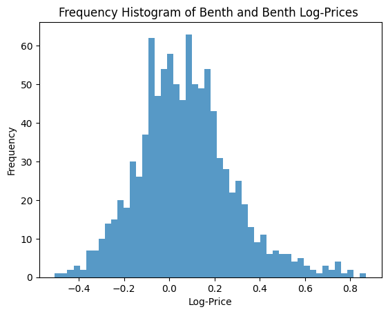

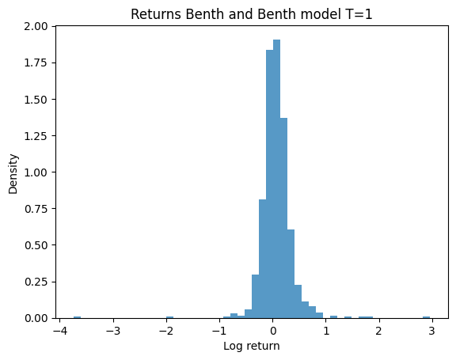

```python
# Calculate log-prices with a filter for positive final prices
log_prices = np.log(S_t[:, -1][S_t[:, -1] > 0] / S0)

# Plot histogram within a specified range to avoid extreme values
plt.hist(log_prices, bins=50, range=[np.percentile(log_prices, 1), np.percentile(log_prices, 99)], alpha=0.75)
plt.xlabel('Log-Price')
plt.ylabel('Frequency')
plt.title('Frequency Histogram of Benth and Benth Log-Prices ')
plt.show()

# Calculate log returns
log_returns = np.log(S_t[:, -1] / S0)
plt.hist(log_returns, bins=50, density=True, alpha=0.75)
plt.title('Returns Benth and Benth model T=1')
plt.xlabel('Log return')
plt.ylabel('Density')
plt.show()
```

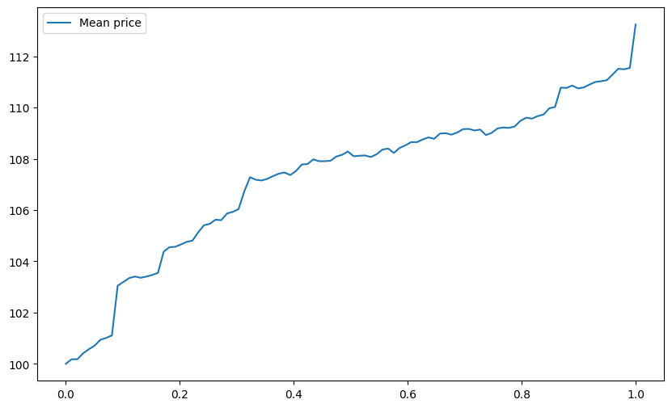

```python
t = np.linspace(0.0, T, int(T / 0.01))
mean_S_t = np.mean(S_t, axis=0)
plt.figure(figsize=(10, 6))
plt.plot(t, mean_S_t, label='Mean price')
plt.legend()
plt.show()
```

```python
t = np.linspace(0.0, T, int(T / 0.01))
forward_prices = []
for i in range(0,int(T / 0.01)):
    forward_prices.append(calculate_future_prices(mean_S_t[i], 0.05, T-(i/int(T / 0.01))))
```

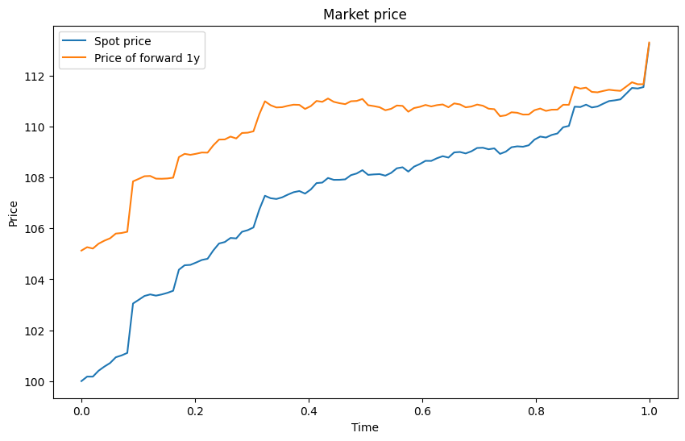

```python
plt.figure(figsize=(10, 6))

# Plot the spot prices
plt.plot(t, mean_S_t, label='Spot price')

# Plot the forward contract prices for October
plt.plot(t, forward_prices, label='Price of forward 1y')


plt.xlabel('Time')
plt.ylabel('Price')
plt.title('Market price')
plt.legend()
```

```python
from scipy.optimize import newton

BS_market = np.zeros_like(mean_S_t)
K = 100
r = 0.05

for i in range(len(mean_S_t)):
    BS_market[i] = (black_scholes_call(mean_S_t[i], K,  T-(i/int(T / 0.01)), r, sigma))
def implied_volatility(S, K, T, r, C_market):
    # Define a function that calculates the difference between the market price and the Black-Scholes price
    def f(sigma):
        return black_scholes_call(S, K, T, r, sigma) - C_market
    sigma_initial_guess = 0.5
    sigma = newton(f, sigma_initial_guess)
    return sigma

# Extract the implied volatility
implied_volatilities = np.zeros_like(mean_S_t)

for i in range(len(implied_volatilities)):
    implied_volatilities[i] = implied_volatility(mean_S_t[i], K,  T, r, BS_market[i])
```

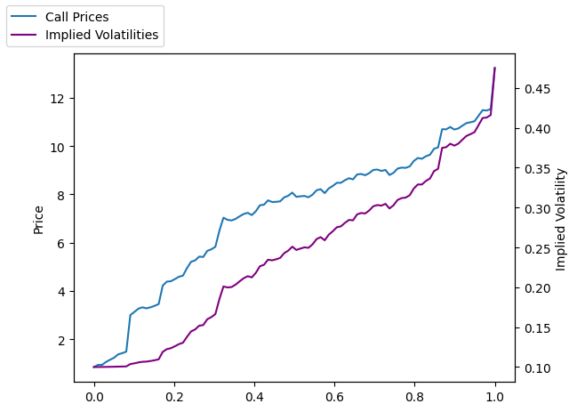

```python
fig, ax1 = plt.subplots()

ax1.plot(t, BS_market, label='Call Prices')
ax1.set_ylabel('Price')

ax2 = ax1.twinx()
ax2.plot(t, implied_volatilities, label='Implied Volatilities', color='purple')
ax2.set_ylabel('Implied Volatility')

fig.legend(loc="upper left")

plt.show()
```

# Question 7

```python
def KOU_MC_OPT(simN, stepsN, S0, K, T, r, q, params):
    """
    Monte Carlo for Kou model

    Parameters
    ----------
    simN : int
        numbers of simmulations
    stepsN : int
        numbers of steps
    S0 : float
        Spot price
    K : float
        Strike price
    T : float
        Time to maturity (in years)
    r : float
        Risk free rate
    q : float
        Continuous dividend yield
    params :
        list of parameters according to the choosen model

    Returns
    -------
    price : arrays
        options paths
    """

    # Merton model scheme in log coordinates

    # Parameters
    sigma, lam, p, lam_plus, lam_minus = params

    # Seeding the Mersenne Twister
    np.random.seed(123)

    dt = T / stepsN

    # Initialize arrays
    price = np.ones((simN, stepsN + 1)) * S0

    # Levy compensator
    jump_compensator = (lam * (p * lam_plus / (lam_plus - 1) + (1 - p) * lam_minus / (1 + lam_minus) - 1))  # *mu

    # Drift
    drift = (r - q - sigma ** 2 / 2 - jump_compensator) * dt * np.ones((simN, stepsN))

    # Brownian increments
    dWt = np.random.normal(0, 1, (simN, stepsN))
    diffusion = sigma * dWt * np.sqrt(dt)

    # Poisson process for jumps
    jump_N = si.stats.poisson.rvs(lam * dt, size=(simN, stepsN))

    jumps = np.zeros((simN, stepsN))

    for i in range(simN):
        for j in range(stepsN):
            for k in range(jump_N[i, j]):
                U = np.random.rand(1)
                jumps[i, j] += np.random.exponential(1 / lam_plus) * (U < p) - np.random.exponential(1 / lam_minus) * (U > p)

    # Price evolution
    price[:, 1:] = S0 * np.exp(np.cumsum(drift + diffusion + jumps, axis=1))

    # Compute the payoff for each simulated price path
    payoff = np.maximum(price[:, -1] - K, 0)

    # Discount the payoffs to get the option price
    price_opt = np.exp(-r * T) * np.mean(payoff)

    return price_opt
```

```python
from scipy.optimize import minimize

def objective_function_mnmz(params, market_prices,strikes, KOU_MC, simN, stepsN, S0, T, r, q):
    """
    Objective function for the calibration of the Kou model.

    Parameters
    ----------
    params : list
        The parameters of the Kou model to be calibrated.
    market_prices : numpy.ndarray
        The market prices.
    KOU_MC : function
        The Kou model function.
    simN : int
        numbers of simulations
    stepsN : int
        numbers of steps
    S0 : float
        Spot price
    T : float
        Time to maturity (in years)
    r : float
        Risk free rate
    q : float
        Continuous dividend yield

    Returns
    -------
    error : float
        The sum of squared differences between the model prices and the market prices.
    """
    for K in strikes:
        model_prices = KOU_MC(simN, stepsN, S0, K,T, r, q, params)
        #print(model_prices)
        error = np.sum((model_prices - market_prices)**2)
    return error
```

```python
import pandas as pd

SPX = pd.read_excel('/SPX options.xlsx')
df_data_spx = SPX[1:11]
df_data_spx['Price'] = (df_data_spx['Bid'] + df_data_spx['Ask'])/2
df_data_spx = df_data_spx.drop(columns=['Ticker','Bid','Ask','IVM','Volm','OInt'])
```

```python
df_data_spx
```

|  | Strike | Price |
| --- | --- | --- |
| 1 | 4820 | 59.949997 |
| 2 | 4825 | 56.449997 |
| 3 | 4830 | 53.150009 |
| 4 | 4835 | 49.949997 |
| 5 | 4840 | 46.949997 |
| 6 | 4845 | 44.100006 |
| 7 | 4850 | 41.050003 |
| 8 | 4855 | 39.000000 |
| 9 | 4860 | 35.650009 |
| 10 | 4865 | 33.199997 |

```python
from scipy.optimize import Bounds
params_initial = [0.131400813, 0.100984056, 0.001259063, 0.001303577, 2.85494576]
bounds = Bounds([0.01, 0, 0, 0.01, 0.01], [2, 100, 1, 10, 10])

market_prices = np.array(df_data_spx['Price'])  # replace with your market prices

result = minimize(objective_function_mnmz, params_initial, args=(market_prices, df_data_spx['Strike'],KOU_MC_OPT, 1000, 100, 4852.24, 0.035, 0, 0), bounds = bounds,method='Nelder-Mead')

params_optimized = result.x
```

```python
params_optimized
```

```
array([1.31478288e-01, 1.02685546e-01, 1.27584741e-03, 1.01218883e-02,
       2.84525539e+00])
```

[output not shown]

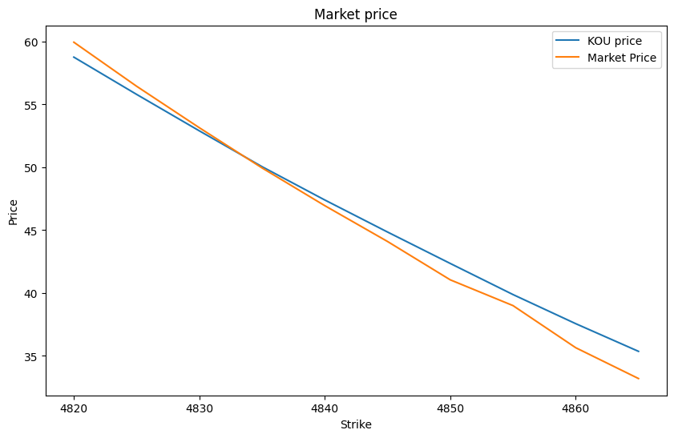

```python
model_prices = []
for i in df_data_spx['Strike']:
    model_prices.append(KOU_MC_OPT(100, 10, 4852.24, i, 0.035, 0, 0, params_optimized))
print(np.sum(model_prices-df_data_spx['Price']))


plt.figure(figsize=(10, 6))
plt.plot(df_data_spx['Strike'], model_prices, label='KOU price')
plt.plot(df_data_spx['Strike'], df_data_spx['Price'], label='Market Price')
plt.xlabel('Strike')
plt.ylabel('Price')
plt.title('Market price')
plt.legend()
```

```python
%%shell
jupyter nbconvert --to html /contenue/drive/MonDrive/ColabNotebooks/Jump Process.ipynb
```

[output not shown]

[output cut: 134 more lines]

[output not shown]

[output not shown]